# Live Register (Construction sector) vs Planning Permissions data: Is there a relationship between the two for Cork city?

```r
library(googleVis)
```

```r
op <- options(gvis.plot.tag='chart')
```

# Part 1 - preparing the data

```r
#These are the packages you need
#install.packages(c("zoo","googleVis","pxR","reshape","sqldf"))
library("zoo")
library("googleVis")
library("pxR")
library("reshape")
library("sqldf")
library("car")
library("MASS")

#read in the following px file: LRM31 from the CSO Statbank: http://www.cso.ie/px/pxeirestat/database/eirestat/Job%20Churn/Job%20Churn_statbank.a
LRM31.px<- read.px("http://www.cso.ie/px/pxeirestat/Database/eirestat/Live%20Register%20Detailed%20Flow%20Analysis/LRM31.px")
#Convert this px file into a data frame
LRM31df<-as.data.frame(LRM31.px)
#We need to reshape the data frame so as we can change the statistic categories into variables which have
#values for Statistic  Month    Social.Welfare.Office   Occupation.Held value
LRM31= dcast(LRM31df, Month   + Social.Welfare.Office + Occupation.Held  ~ Statistic, value.var="value", fun.aggregate=sum)
#we are going to look at data for Construction workers in Cork city so we can create a smaller dataset which just these categories
sub1<-subset(LRM31, Social.Welfare.Office == "Cork City")
sub2<-subset(sub1, Occupation.Held == "Construction, woodwork and metal and related industries")
names(sub2)
```

```
## [1] "Month"
## [2] "Social.Welfare.Office"
## [3] "Occupation.Held"
## [4] "Live register (Persons)"
## [5] "Stayers (Persons)"
## [6] "Joiners (Persons)"
## [7] "Leavers (Persons)"
## [8] "Leavers identified with P35 employment (Persons)"
```

```r
ourdata<-c(sub2[1:3], sub2[7])

dates = strsplit(as.character(ourdata$Month), "M")

d=NULL
for (i in 1:45){

  #put in format year, day = 01 , month,
d[i] <-(paste(dates[[i]][1], dates[[i]][2],"01", sep = "-"))


}

d<-as.data.frame(d)
c<-rbind("2011Q2", "2011Q2", "2011Q2", "2011Q3", "2011Q3", "2011Q3", "2011Q4", "2011Q4", "2011Q4" ,
"2012Q1", "2012Q1", "2012Q1", "2012Q2", "2012Q2", "2012Q2", "2012Q3", "2012Q3", "2012Q3", "2012Q4", "2012Q4", "2012Q1",
"2013Q1" ,"2013Q1", "2013Q1", "2013Q2", "2013Q2", "2013Q2", "2013Q3", "2013Q3", "2013Q3", "2013Q4", "2013Q4", "2013Q4",
"2014Q1" ,"2014Q1", "2014Q1", "2014Q2", "2014Q2", "2014Q2", "2014Q3", "2014Q3", "2014Q4", "2014Q4", "2014Q4","2015Q1")
c<-as.data.frame(c)
e<-c(d,c)
e<-as.data.frame(e)
f <- rename(e, c(V1="quarter"))
g<-cbind(as.data.frame(ourdata),as.data.frame(f))

#ignore the NAs and using the aggregate function get the mean of the "Leavers..Persons." values for each quarter, i.e the months in each quarter are added together
#and divided by the corresponding number of months which there is a value for. So in a quarter with 3 months and one NA, the values for two months are added together and divided
#by two to get the mean.
live<-dcast(g, quarter ~ Occupation.Held, value.var="Leavers..Persons.", fun.aggregate=mean,na.rm=TRUE)

#Read in the planning permissions data from the CSO statbank
BHQ02.px<- read.px("http://www.cso.ie/px/pxeirestat/Database/eirestat/Planning%20Permissions/BHQ02.px")
#Convert this px file into a data frame
BHQ02df<-as.data.frame(BHQ02.px)
#We need to reshape the data frame so as we can change the statistic categories into variables which have
#values for Type.of.Dwelling ,  Quarter,    Region.and.County and statistic
BHQ02= dcast(BHQ02df, Quarter   + Type.of.Dwelling + Region.and.County  ~ Statistic, value.var="value", fun.aggregate=sum)

sub1<-subset(BHQ02, Region.and.County == "Cork City")
plandata<-sub1[1:4]
plan<-dcast(plandata, Quarter~Type.of.Dwelling , value.var="Planning Permissions Granted (Number)", fun.aggregate=sum)
plan[is.na(plan)] <- 0
#g[is.na(g)] <- 0
plan2<-cbind(plan,rowSums(plan[2:5]))
#join the live register data and planning permissions data by quarter so that the will cover the same periods.
newdata<-sqldf("select * from plan2 join live
      where plan2.Quarter = live.quarter")
newdata <- rename(newdata, c(rowSums_plan_2_5__="planning"))
newdata <- rename(newdata, c(Construction__woodwork_and_metal_and_related_industries="livereg"))
newdata$livereg<-round(newdata$livereg,0)
```

# let’s take a quick look at the outputs:

```r
head(newdata)
```

```
##   Quarter Houses Multi_development_houses One_off_houses
## 1  2011Q2      6                        0              6
## 2  2011Q3      6                       14              5
## 3  2011Q4      8                        2              6
## 4  2012Q1      7                        1              6
## 5  2012Q2      8                        2              6
## 6  2012Q3      5                        0              5
##   Private_flats_apartments planning quarter livereg
## 1                        1       13  2011Q2     305
## 2                        1       26  2011Q3     467
## 3                        0       16  2011Q4     233
## 4                        1       15  2012Q1     262
## 5                        4       20  2012Q2     293
## 6                        2       12  2012Q3     323
```

```r
summary(newdata)
```

```
##     Quarter       Houses      Multi_development_houses One_off_houses
##  2011Q2 : 1   Min.   :3.000   Min.   : 0.000           Min.   :2.000
##  2011Q3 : 1   1st Qu.:5.000   1st Qu.: 0.000           1st Qu.:5.000
##  2011Q4 : 1   Median :6.500   Median : 2.000           Median :5.500
##  2012Q1 : 1   Mean   :6.562   Mean   : 2.188           Mean   :5.188
##  2012Q2 : 1   3rd Qu.:8.000   3rd Qu.: 2.250           3rd Qu.:6.000
##  2012Q3 : 1   Max.   :9.000   Max.   :14.000           Max.   :7.000
##  (Other):10
##  Private_flats_apartments    planning        quarter      livereg
##  Min.   :0.000            Min.   :10.00   2011Q2 : 1   Min.   :190.0
##  1st Qu.:1.000            1st Qu.:12.75   2011Q3 : 1   1st Qu.:217.5
##  Median :1.500            Median :15.00   2011Q4 : 1   Median :259.5
##  Mean   :1.938            Mean   :15.88   2012Q1 : 1   Mean   :268.6
##  3rd Qu.:3.000            3rd Qu.:19.00   2012Q2 : 1   3rd Qu.:296.0
##  Max.   :4.000            Max.   :26.00   2012Q3 : 1   Max.   :467.0
##                                           (Other):10
```

```r
levels(newdata$quarter)
```

```
##  [1] "2011Q2" "2011Q3" "2011Q4" "2012Q1" "2012Q2" "2012Q3" "2012Q4"
##  [8] "2013Q1" "2013Q2" "2013Q3" "2013Q4" "2014Q1" "2014Q2" "2014Q3"
## [15] "2014Q4" "2015Q1"
```

# Part 2. Now let’s look at plots of the ‘livereg’ and ‘planning’ elements of our data.

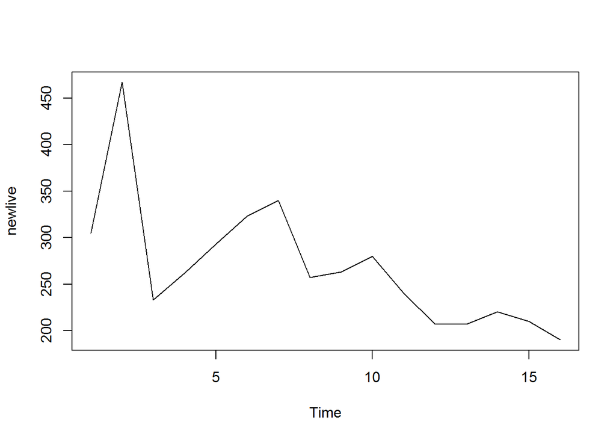

```r
newlive<-as.ts(newdata$livereg)
plot.ts(newlive)
```

The number of construction workers leaving the live register in Cork city has taken declined in this period.

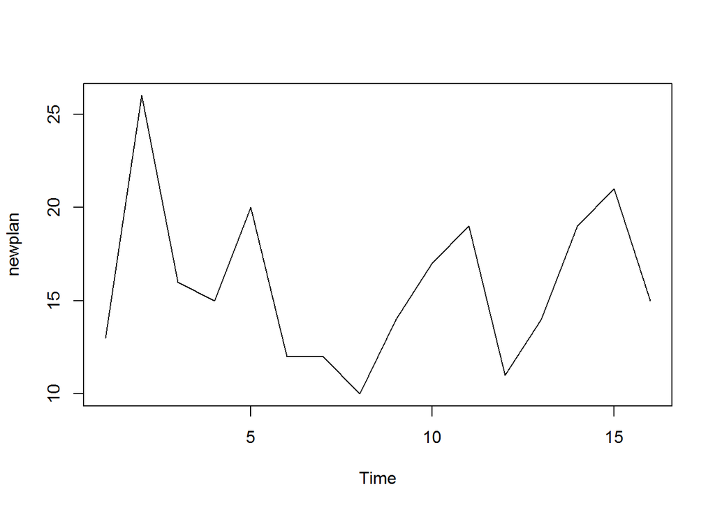

```r
newplan<-as.ts(newdata$planning)
plot.ts(newplan)
```

There are seasonal fluctuations in planning permission applications for Cork city.

Let’s look at the two time series data in one plot. This is not too scale. But it is useful to visually assess if there is a relationship.

```r
comp<- gvisLineChart(newdata, "Quarter", c("planning","livereg"),
                         options=list(
                           #set the size of the chart
                           height=600,width=1000,
                           #add a title and set the font type and size
                           title="Planning Permissions Granted v Live Register",
                           titleTextStyle="{fontSize:16}",
                           #set the colour of the lines
                           series="[{color:'green', targetAxisIndex: 0}, {color:'red',targetAxisIndex:1}]"
                         ))

plot(comp)
```

[output not shown]

As discussed above there is a seasonal pattern to the planning permissions data. If there was a relationship, one might anticipate a similar seasonal pattern with the live register data. However although there is initial evidence of a similar pattern, the number leaving the live register is not as closely linked to the number of planning permissions granted as time goes on. This could have been because for the initial quarters recruitment started as soon as permission was granted. It could also have been coincidental as workers were signing off the register for different reasons such as emigration or work elsewhere in the country and the patterns just happened to match at this time. Later planning permissions granted did not seem to have the same impact on the live register. Indeed although planning permissions retained their seasonality, the number of construction workers signing off the live register continued on a decline.

However, let’s back this visual analysis with some regression analysis.

assumptions:

1. independent and identically distributed (iid) normal variables.
2. observations between quarters are independent.
3. the time series covered by the data is indicative of a broader time scale.

Generally speaking there is a doubt about the autocorrelation of errors in time series data. In this case however, the numbers leaving the live register and number of permissions granted can be assumed to be independent of previous quarters.

```r
lm<-lm(newdata$livereg~newdata$planning)
summary(lm)
```

```
##
## Call:
## lm(formula = newdata$livereg ~ newdata$planning)
##
## Residuals:
##    Min     1Q Median     3Q    Max
## -87.85 -47.53  -0.35  29.73 140.57
##
## Coefficients:
##                  Estimate Std. Error t value Pr(>|t|)
## (Intercept)       177.833     66.451   2.676   0.0181 *
## newdata$planning    5.715      4.052   1.411   0.1802
## ---
## Signif. codes:  0 '***' 0.001 '**' 0.01 '*' 0.05 '.' 0.1 ' ' 1
##
## Residual standard error: 66.79 on 14 degrees of freedom
## Multiple R-squared:  0.1244, Adjusted R-squared:  0.06191
## F-statistic:  1.99 on 1 and 14 DF,  p-value: 0.1802
```

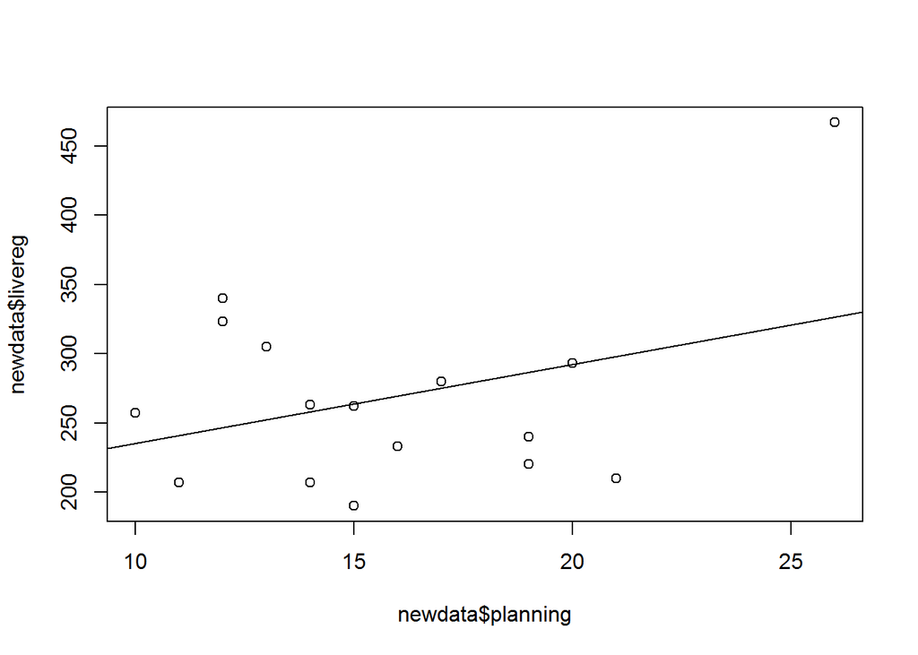

```r
plot(newdata$planning,newdata$livereg)
abline(lm)
```

Multiple R-squared: 0.1245

12.45 % of the variability in the live register can be explained by the regression on the planning permissions data. This is low and suggests a poor relationship.

F-statistic is 1.99/t- value is 1.411 .

P value ( 0.1801) is greater than 5% so accept null hypothesis. There is no relationship between the planning permissions and the numbers leaving the live register.

Planning permissions granted data should not be used to predict the numbers leaving the live register data for Cork city.

# What can we take from this ?

The planning data is confined to residential property, so perhaps if commercial planning permissions were included, it may change the output.

We can see from our brief look at the data above that there was a sharp rise in the number of “Multi_development_houses” permissions granted in 2011Q3. The labour intensive and large scale nature of such developments may explain the concurrent rise in numbers of construction workers siging off in that period.

```r
 head(newdata)
```

```
##   Quarter Houses Multi_development_houses One_off_houses
## 1  2011Q2      6                        0              6
## 2  2011Q3      6                       14              5
## 3  2011Q4      8                        2              6
## 4  2012Q1      7                        1              6
## 5  2012Q2      8                        2              6
## 6  2012Q3      5                        0              5
##   Private_flats_apartments planning quarter livereg
## 1                        1       13  2011Q2     305
## 2                        1       26  2011Q3     467
## 3                        0       16  2011Q4     233
## 4                        1       15  2012Q1     262
## 5                        4       20  2012Q2     293
## 6                        2       12  2012Q3     323
```

```r
newdata[1:6]
```

```
##    Quarter Houses Multi_development_houses One_off_houses
## 1   2011Q2      6                        0              6
## 2   2011Q3      6                       14              5
## 3   2011Q4      8                        2              6
## 4   2012Q1      7                        1              6
## 5   2012Q2      8                        2              6
## 6   2012Q3      5                        0              5
## 7   2012Q4      5                        2              3
## 8   2013Q1      3                        1              2
## 9   2013Q2      6                        0              6
## 10  2013Q3      8                        3              5
## 11  2013Q4      8                        2              6
## 12  2014Q1      5                        0              5
## 13  2014Q2      5                        0              5
## 14  2014Q3      9                        2              7
```

[output cut: 19 more lines]

The “planning” variable used in the regression analysis above is the sum of the variables: “Houses” , “Multi_development_houses” , “One_off_houses” and “Private_flats_apartments”.

# Let’s take a look at the relationship between “Multi_development_houses” only and the Live Register.

```r
multi<- gvisLineChart(newdata, "Quarter", c("Multi_development_houses","livereg"),
                     options=list(
                       #set the size of the chart
                       height=600,width=1000,
                       #add a title and set the font type and size
                       title="Multi Development Houses Permissions Granted v Live Register",
                       titleTextStyle="{fontSize:16}",
                       #set the colour of the lines
                       series="[{color:'green', targetAxisIndex: 0}, {color:'red',targetAxisIndex:1}]"
                     ))

plot(multi)
```

[output not shown]

The number of plannings permissions for multi development housing retains a cyclicality, whereas obviously the numbers signing off the live register shows the same decline as in the relevant plots above. We can see that there is indeed a relationship for the period surrounding 2011Q3, which suggests that this is linked to the higher number of permissions granted at that time. After this period the number of multi development unit permissions is significantly lower, however there appears to be a stronger relationship beween the two than that outlined above.

# Let’s see how this visual synopsis checks out with regression analysis.

```r
lm2<-lm(newdata$livereg~newdata$Multi_development_houses)
summary(lm2)
```

```
##
## Call:
## lm(formula = newdata$livereg ~ newdata$Multi_development_houses)
##
## Residuals:
##     Min      1Q  Median      3Q     Max
## -89.895 -31.526   2.553  28.710  84.948
##
## Coefficients:
##                                  Estimate Std. Error t value Pr(>|t|)
## (Intercept)                       238.052     15.824  15.044  4.9e-10 ***
## newdata$Multi_development_houses   13.948      4.044   3.449  0.00391 **
## ---
## Signif. codes:  0 '***' 0.001 '**' 0.01 '*' 0.05 '.' 0.1 ' ' 1
##
## Residual standard error: 52.48 on 14 degrees of freedom
## Multiple R-squared:  0.4594, Adjusted R-squared:  0.4208
## F-statistic:  11.9 on 1 and 14 DF,  p-value: 0.003911
```

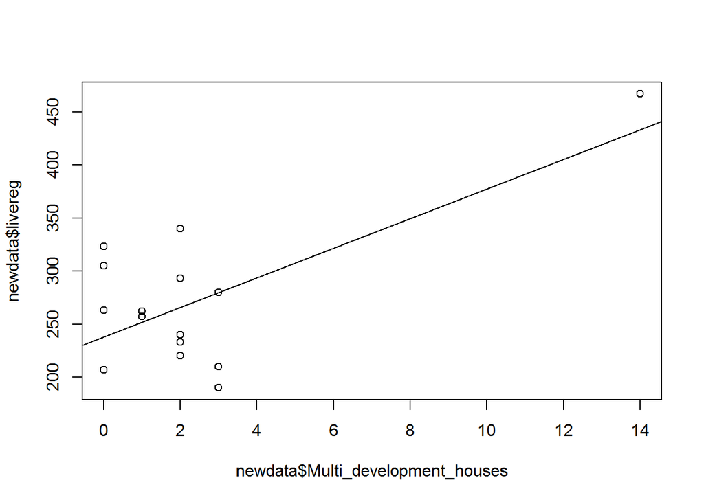

```r
plot(newdata$Multi_development_houses,newdata$livereg)
abline(lm2)
```

Multiple R-squared: 0.4594

45.94 % of the variability in the live register can be explained by the regression on the Multi development houses. This is low and suggests a stronger relationship than that above, however it is mild.

F-statistic: 11.9 on 1 and 14 DF, p-value: 0.003911

P value ( 0.003911) is less than 5% so reject null hypothesis. There is a relationship between Multi development houses and the numbers leaving the live register.

Planning permission approvals for Multi development houses can be used to predict the numbers leaving the live register data for Cork city. However, because of the low R-squared value we should do some further analysis on our data.

```r
# Evaluate Collinearity
durbinWatsonTest(lm2)
```

```
##  lag Autocorrelation D-W Statistic p-value
##    1       0.5928672     0.4884617       0
##  Alternative hypothesis: rho != 0
```

The p-value in the durbin Watson test is zero, so we can conclude in fact that there is auto-correlation amongst the residuals between live register and multi house developments. It was assumed above that the number signing off the live register was indepdendent of the previous quarter, in that unlike currencies for example, the number signing off the live register was not related to the previous quarter. This is because they were not following on from the previous quarter, but rather were new. However, our evidence suggests there is a high correlation between the errors for the live register regressed on multi house developments. As both of these sets of measurements are per quarter, one can therefore infer that the cyclical nature of permissions granted does impact on the numbers signing off the live register. In other words there is a dependence between the number of permissions granted and the number leaving the live register per quarter. Steps to remedy this auto-correlation would be to:

extend the time periods from quarterly to half-yearly or yearly

include a linear term to ‘smooth’ out the cyclicalities

include seasonal dummy variables, where at any point in the time series, t, one variable will equal 1 and the other variables 0

Use transformed Variables that remove the (estimated) autocorrelation parameter (Cochrane-Orcutt and Hildreth-Lu Procedures)

Use First Differences, where the first difference of Y at period t is equal to Yt-Yt-1

Use a more sophisticated forecasting model such as exponential smoothing or ARIMA may be appropriate

Use Estimated Generalized Least Squares

# So it looks like we can’t trust the results from the analysis above: the regression model is likely to be seriously biased or misleading.

# But, although we know that we can’t use the model, let’s see what emerges from the diagnostic tests below.

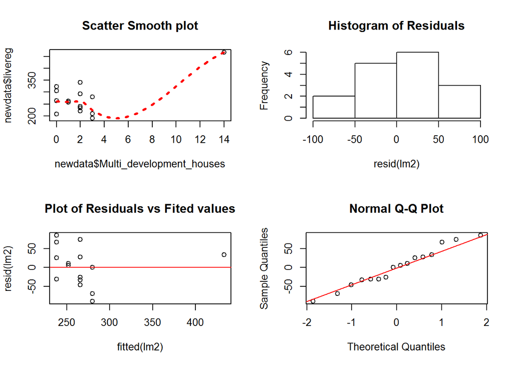

```r
layout(matrix(1:4,2,2))
 with(newdata, scatter.smooth(newdata$Multi_development_houses,newdata$livereg, lpars= list(col = "red", lwd = 3, lty = 3)))
 title("Scatter Smooth plot")
plot(fitted(lm2),resid(lm2),main="Plot of Residuals vs Fited values")
abline(h=0, col = "red")
hist(resid(lm2),main="Histogram of Residuals")
qqnorm(resid(lm2))
qqline(resid(lm2), col = "red")
```

```r
par(mfrow=c(1,1))
shapiro.test(residuals(lm2))
```

```
##
##  Shapiro-Wilk normality test
##
## data:  residuals(lm2)
## W = 0.9701, p-value = 0.8407
```

The Shapiro-Wilk normality test shows that the p-value is greater than 5%, so we can conclude that the residuals follow a normal distribution and thus sum to zero. This is corroborated by the histogram which suggests a normal distribution.

The small number of observations is noticeable in these plots.

The scatter smooth suggests a non-linear negative relationship that is greatly influenced into becoming postive by the outlier. The variance appears to be constant but systematic- so the errors are not independent.

In the plot of residuals vs fitted values the residuals do not bounce randomly around the 0 line. Infact there is evidence that certain values appear to be grouped around certain points in time, i.e. cyclicality. This suggests that the assumption that the relationship is linear is not strong.

However, the residuals roughly form a “horizontal band” around the 0 line. This suggests that the variances of the error terms are equal,even if they are not independent.

One residual does “stand out” from the basic random pattern of residuals. This suggests that there is an outlier and that it is likey to have high leverage.

In the normal Quantile-Quantile plot, there are slight departures above and below the reference line, however on balance the residuals appear to follow a normal distribution.

We can conclude that the relationship is not linear and the errors are not independent and are not randomly distributed. So we can’t use this model.

# Now, just for information purposes again, let’s see how we identify the outlier:

We know from looking at the data above that 2011Q3 is the outlier, however this is how we identify it in R.

```r
studres(lm2)
```

```
##            1            2            3            4            5
##  1.380514716  2.190908795 -0.634461170  0.190759335  0.518341280
##            6            7            8            9           10
##  1.835691892  1.524882481  0.095283244  0.484756427  0.001995503
##           11           12           13           14           15
## -0.496750957 -0.606376297 -0.606376297 -0.898034164 -1.428695757
##           16
## -1.939828802
```

```r
fit <- lm2
outlierTest(fit)
```

```
##
## No Studentized residuals with Bonferonni p < 0.05
## Largest |rstudent|:
##   rstudent unadjusted p-value Bonferonni p
## 2 2.190909            0.04728      0.75648
```

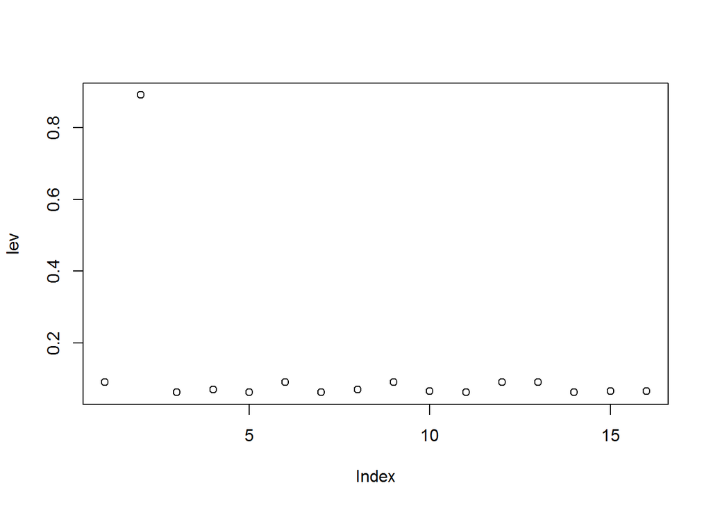

```r
#High leverage
lev = hat(model.matrix(fit))
plot(lev)
```

```r
lev
```

```
##  [1] 0.09090909 0.89090909 0.06270872 0.07087199 0.06270872 0.09090909
##  [7] 0.06270872 0.07087199 0.09090909 0.06641929 0.06270872 0.09090909
## [13] 0.09090909 0.06270872 0.06641929 0.06641929
```

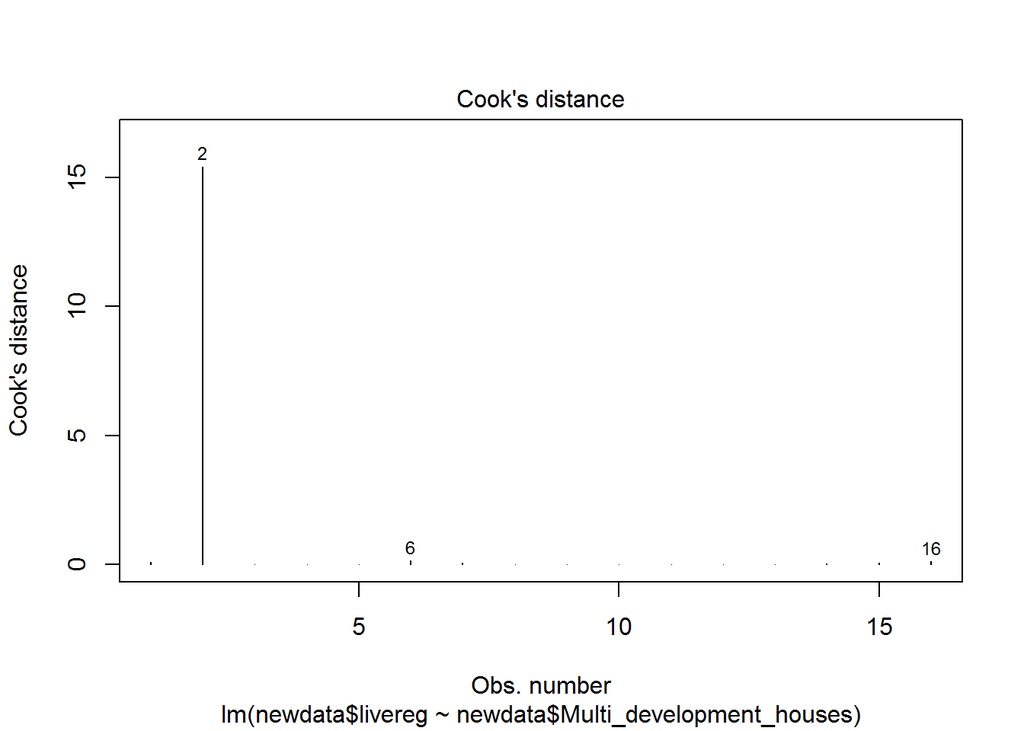

```r
#Cook's distance
cutoff <- 4/((nrow(newdata)-length(fit$coefficients)-2))
plot(fit, which=4, cook.levels=cutoff)
```

```r
newdata$Multi_development_houses[2]
```

```
## [1] 14
```

```r
newdata$livereg[2]
```

```
## [1] 467
```

```r
newdata$quarter[2]
```

```
## [1] 2011Q3
## 16 Levels: 2011Q2 2011Q3 2011Q4 2012Q1 2012Q2 2012Q3 2012Q4 ... 2015Q1
```

What would we do with the outlier if we could use the above model ?

We should not remove the outlier as the data period and the number of obserations are quite small. For example the data period does not cover the Celtic Tiger period where it is quite likely that 14 or more mutli developments were approved quite often, thus also having an effect on the live register- however, we need also to remember that at that period there was also recruitment from other countries, so it also possible that the effect on the register was minimal. In essence rather than remove the outlier from the data, it is safer to conclude that the data set is too small. While there are indications that the higher the number of multi development permissions granted for Cork city in a quarter- the higher the number of construction workers in Cork city that sign off the live register- the above diagnostics would query the use of a data set of this size (and perhaps time intervals) for such predictions.

# A little off-point but let’s make a prediction for the next two quarters (2015 Q2 and Q3) of the numbers of construction workers signing off the live register data.

```r
fit <- arima(newlive, order=c(1,0,0), list(order=c(2,1,0), period=2))
fit
```

```
##
## Call:
## arima(x = newlive, order = c(1, 0, 0), seasonal = list(order = c(2, 1, 0), period = 2))
##
## Coefficients:
##          ar1     sar1    sar2
##       0.0850  -0.4783  0.1897
## s.e.  0.2755   0.3232  0.3276
##
## sigma^2 estimated as 3905:  log likelihood = -78.26,  aic = 164.52
```

```r
fore <- predict(fit, n.ahead=2)
fore
```

```
## $pred
## Time Series:
## Start = 17
## End = 18
## Frequency = 1
## [1] 201.4615 206.7437
##
## $se
## Time Series:
## Start = 17
## End = 18
## Frequency = 1
## [1] 62.49270 62.71793
```

```r
# error bounds at 95% confidence level
U <- fore$pred + 2*fore$se
L <- fore$pred - 2*fore$se
U
```

```
## Time Series:
## Start = 17
## End = 18
## Frequency = 1
## [1] 326.4469 332.1796
```

```r
L
```

```
## Time Series:
## Start = 17
## End = 18
## Frequency = 1
## [1] 76.47615 81.30787
```

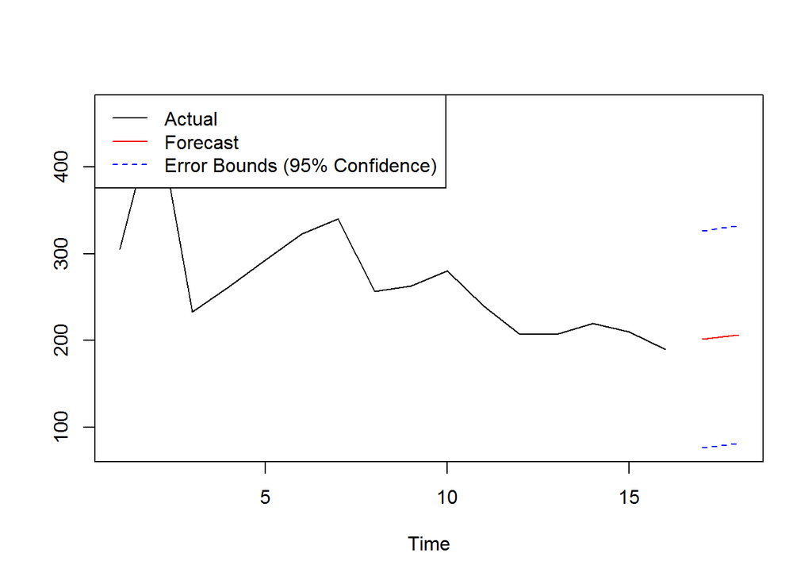

```r
ts.plot(newlive, fore$pred, U, L, col=c(1,2,4,4), lty = c(1,1,2,2))
legend("topleft", c("Actual", "Forecast", "Error Bounds (95% Confidence)"),
 col=c(1,2,4), lty=c(1,1,2))
```

```r
## Set options back to original options
options(op)
```